# Stats

Панюшев Николай

14 ноября 2017 г

# Все графики и статистический анализ здесь

```r
setwd("Script_files/")
unzip(zipfile = "all_bins.zip")
all_bins <- fread("all_bins.tsv")
file.remove("all_bins.tsv")
```

## Оценка вероятности получить общие бины случайно

Концепция такая - надо нагенерить случайные данные, чтобы они выглядели примерно как то, что мы видим в реальных данных. Для этого сгенерируем 14 (по количеству использованных клеточных линий) векторов с бинами.

Поэтому порежем геном на кусочки, в каждом из которых есть примерно столько бинов, сколько и в реальных данных.

В качестве иллюстрации посмотрим на распределение по 1й хромосоме бинов во всех клеточных линиях

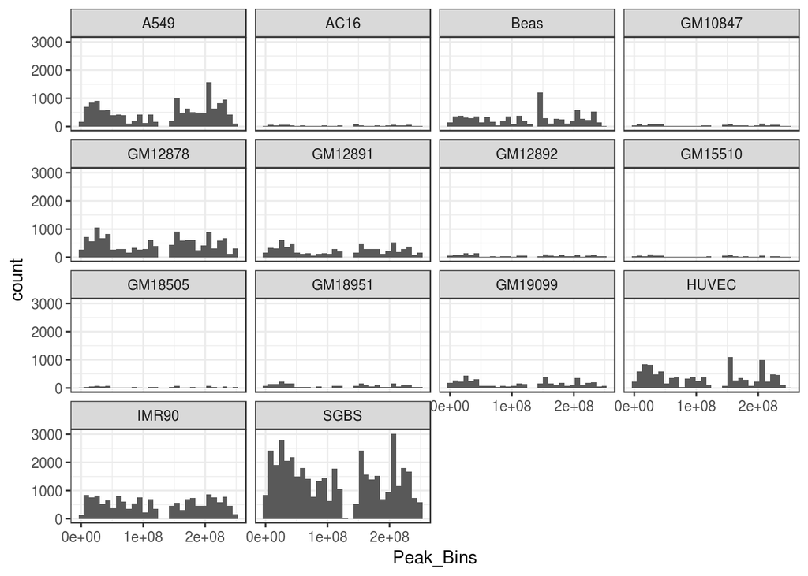

```r
ggplot(all_bins[Chromosome=="chr1", ,], aes(Peak_Bins))+
         geom_histogram()+
  facet_wrap(~ Cell_line)+
  theme_bw()
```

По графику видно, что количество пиков очень сильно варьирует, но профиль повторяется, пиков нет в центромерном участке, например.

Вне этих пределов не имеет смысла генерировать бины, потому что их нет в реальных данных совсем.

```r
piece_size = 1000
bins_regions <- seq(min(all_bins$Peak_Bins), max(all_bins$Peak_Bins), by = piece_size) #Определили координаты начала участков, где будем пики генерить
```

Cделаем data.table - где будет начало региона, минимальное, среднее и максимальное по всем линиям количество бинов, которые в этом регионе встречаются

```r
setwd("Script_files/")
if (!file.exists("regions_bins.tsv")){
  Cell_line_matrix <- matrix(data = unique(all_bins$Cell_line), ncol = length(unique(all_bins$Cell_line)),
                        nrow = length(bins_regions), dimnames = list(bins_regions, unique(all_bins$Cell_line)))
  Regions_matrix <- matrix(bins_regions, ncol = length(unique(all_bins$Cell_line)),
                        nrow = length(bins_regions))
  new_array <- array (c(Cell_line_matrix, Regions_matrix), dim = c(length(unique(all_bins$Cell_line)),
                        length(bins_regions), 2))
  sel_bins <- all_bins[, .(Cell_line, Peak_Bins)]

  bin_num <- function(vector){
   cell_line <- vector[1]
   region <- as.numeric(vector[2])
   bins <- sel_bins[Cell_line == cell_line, Peak_Bins]
   bins <- bins[bins > region & bins < region + piece_size]
  return(length(bins))
  }

  bin_number_dt <- apply(new_array, c(2,1), bin_num)
  bin_number_dt <- as.data.table(bin_number_dt)
  names(bin_number_dt) <- unique(all_bins$Cell_line)
  fwrite(bin_number_dt, "regions_bins.tsv", sep = "\t")
}else{
  bin_number_dt <- fread("regions_bins.tsv", sep = "\t")
}

to_generate_dt <- data.table(Regions = bins_regions)
to_generate_dt$min <- sapply(bin_number_dt, min)
to_generate_dt$mean <- round(sapply(bin_number_dt, mean), digits = 0)
to_generate_dt$max <- sapply(bin_number_dt, max)
to_generate_dt <- to_generate_dt[mean != 0]   #Выбросим пустые регионы, где в среднем нет бинов, только выбросы какие-то
```

Сделаем функцию, которая нам нагенерит вектора

```r
generate_vector <- function(df, piece_size, bin_size = 50){
  df$data <- mapply(runif, runif(1, df$min, df$max), min = df$Regions, max = (df$Regions + piece_size),
                              SIMPLIFY = F)
  out_vector <- unlist(lapply(df$data, round))
  out_vector <-  out_vector%/%bin_size*bin_size
  out_vector <- sort(out_vector)
  #out_vector[length(vector): piece_size/bin_size*length(df$Regions)] <- NA
  return(out_vector)
}
```

Теперь сделаем лист, внутри которой будем пересекать бины количество рядов матрички - 248917, количество столбцов - 25, этого будет достаточно для генерации 1000 уникальных сочетаний по 14 линиям

```r
intersect_list <- matrix(NA, nrow=length(to_generate_dt$Regions), ncol = 25)
intersect_list <- apply(intersect_list, 2, function(x) generate_vector(to_generate_dt, piece_size)) #Так как длина столбцов разная, то будет лист
```

Наконец-то попробуем пересечь бины матрички так и получить вектор с количеством общих бинов Сделаем функцию для этого

```r
inter_len <- function(num_vector, mx=intersect_list){
  my_vec1 <- Reduce(intersect, mx[num_vector])
  return(length(my_vec1))
}
```

Теперь сделаем датафрейм такой же, как мы делали для пересечений линий, с тем лишь отличием, что для каждого пересечения у нас будет 500 точек

```r
n_lines <- length(unique(all_bins$Cell_line))
if (!file.exists("Script_files/gen_combinations.tsv")){
  generated_df <- as.list(seq(1,n_lines))
  generated_df <- lapply(generated_df, function(x) replicate(500, inter_len(sample(1:length(intersect_list), x))))
  generated_df <- as.data.table(generated_df)
  names(generated_df) <- as.character(seq(1,n_lines))
  # Преобразуем его в двухстолбчачтый
  generated_df <- as.data.table(t(generated_df))
  generated_df$Line_number <- c(1:n_lines)
  generated_df <- melt(generated_df, id="Line_number")
  generated_df$Bin_numbers <- generated_df$value
  generated_df$variable <- NULL
  generated_df$value <- NULL
  # Запишем в файл
  fwrite(generated_df, file = "Script_files/gen_combinations.tsv", sep = "\t")
}
generated_df <- fread("Script_files/gen_combinations.tsv", sep = "\t")
```

## График по сочетаниям

Теперь построим график по количеству бинов во всех возможных пересечениях

```r
setwd("Script_files/")
if (!file.exists("combinations.tsv")){
  bins_intersect(all_bins)
}
comb_df <- fread("combinations.tsv", "\t")
```

Построим график для “Естетственных пересечений”

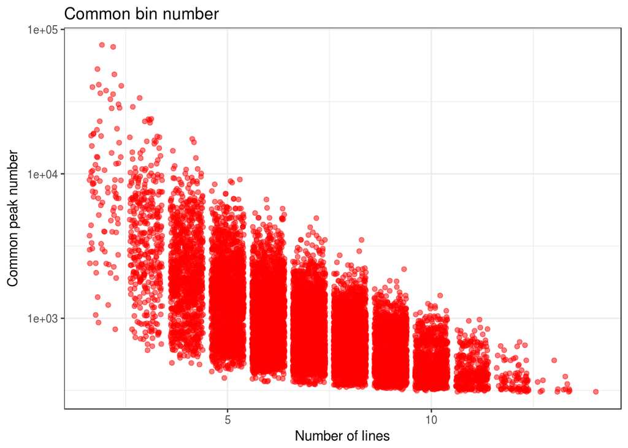

А теперь график для сгенерированных сочетаний

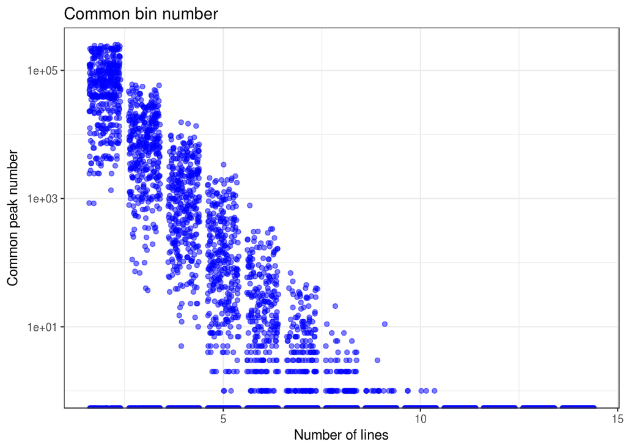

Попробуем сопоставить графички, чтобы были вместе

```r
#Для этого состакаем датафреймы
comb_df$type <- "natural"
generated_df$type <- "unnatural"
all_df <- rbind(comb_df, generated_df)
ggplot(all_df[Line_number>=2, ], aes(x = Line_number, y = Bin_numbers))+
  geom_histogram(position = "dodge", alpha = 0.5, size = 1.5, na.rm = T)+
  #position_dodge()+
  labs(title = "Common bin number",
       x = "Number of lines",
       y = "Common peak number")+
  #scale_y_log10()+
  #ylim(0, 2e+04)+
theme_bw()
```

[output not shown]

Проверим теперь это t- тестом

```r
t.test(comb_df[comb_df$Line_number==4, Bin_numbers], generated_df[generated_df$Line_number==4, Bin_numbers], alternative = "greater")
```

```
##
##  Welch Two Sample t-test
##
## data:  comb_df[comb_df$Line_number == 4, Bin_numbers] and generated_df[generated_df$Line_number == 4, Bin_numbers]
## t = 10.173, df = 921.88, p-value < 2.2e-16
## alternative hypothesis: true difference in means is greater than 0
## 95 percent confidence interval:
##  996.063     Inf
## sample estimates:
## mean of x mean of y
##  2500.445  1312.032
```

```r
comb_df[, round(mean(Bin_numbers), digits = 0), by = Line_number] # В естественных пересечениях
```

```
##     Line_number    V1
##  1:           1 92315
##  2:           2 13180
##  3:           3  4714
##  4:           4  2500
##  5:           5  1617
##  6:           6  1166
##  7:           7   898
##  8:           8   724
##  9:           9   602
## 10:          10   512
## 11:          11   443
## 12:          12   389
## 13:          13   346
## 14:          14   310
```

```r
generated_df[, round(mean(Bin_numbers), digits = 0), by = Line_number] # В сгенерированных пересечениях
```

```
##     Line_number     V1
##  1:           1 496304
##  2:           2  63220
##  3:           3   8518
##  4:           4   1312
##  5:           5    200
##  6:           6     24
##  7:           7      3
##  8:           8      0
##  9:           9      0
## 10:          10      0
## 11:          11      0
## 12:          12      0
## 13:          13      0
## 14:          14      0
```

Всего вышло 310 общих бинов

## Зафиттим модельку и найдем предел

### Реальные пересечения

Я тут конкретно подозреваю обратно-пропорциональную зависимость Ну убедимся в этом! Зафиттим обратно-пропорциональную зависимость по средним значениям

```r
#Для начала попробуем зафиттить по средним
temp_natural <- comb_df[, round(mean(Bin_numbers), digits = 0), by = Line_number]
fit_mean_natural <- lm(Line_number ~ I(1/V1), temp_natural)

#Что мы имеем
summary(fit_mean_natural)
```

```
##
## Call:
## lm(formula = Line_number ~ I(1/V1), data = temp_natural)
##
## Residuals:
##     Min      1Q  Median      3Q     Max
## -1.2531 -0.2829  0.1724  0.4035  0.5006
##
## Coefficients:
##              Estimate Std. Error t value Pr(>|t|)
## (Intercept)    2.2114     0.2401   9.211 8.64e-07 ***
## I(1/V1)     3850.6461   139.4189  27.619 3.13e-12 ***
## ---
## Signif. codes:  0 '***' 0.001 '**' 0.01 '*' 0.05 '.' 0.1 ' ' 1
##
## Residual standard error: 0.5419 on 12 degrees of freedom
## Multiple R-squared:  0.9845, Adjusted R-squared:  0.9832
## F-statistic: 762.8 on 1 and 12 DF,  p-value: 3.134e-12
```

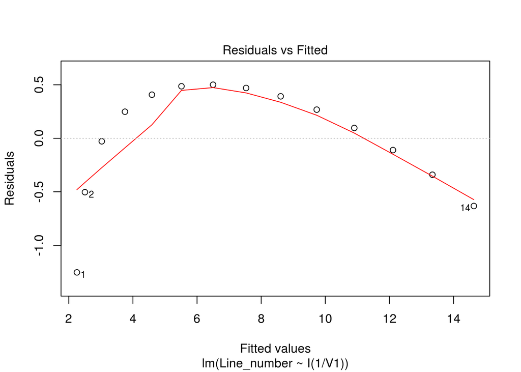

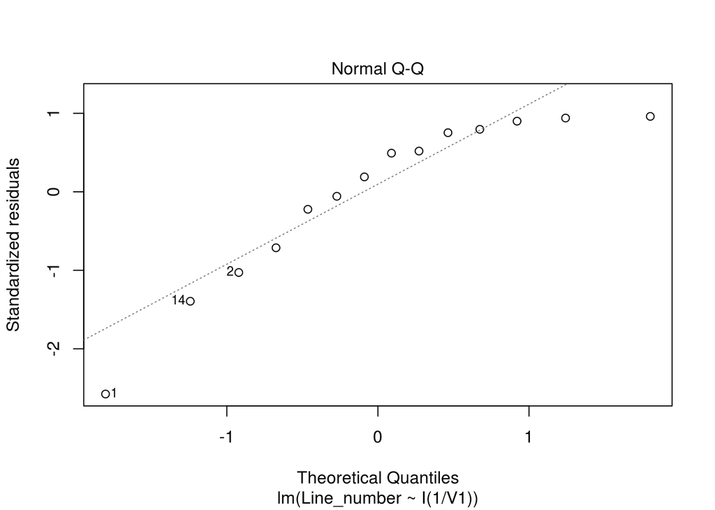

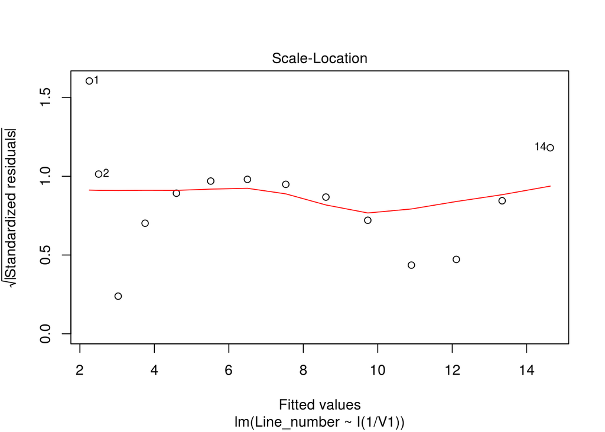

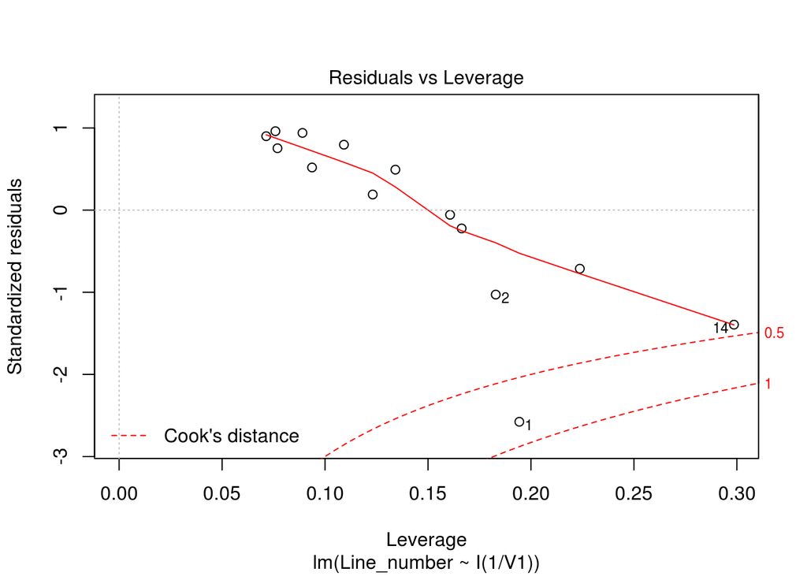

```r
#Выглядит неплохо

#Немного непонятных метрик
plot(fit_mean_natural)
```

Вроде как подтвердили, что зависимость есть, давай теперь попробуем получить реальные значения по всем точкам

```r
fit_natural <- lm(Line_number ~ I(1/Bin_numbers), comb_df[Line_number>1, ])
#Что мы имеем
summary(fit_natural)
```

```
##
## Call:
## lm(formula = Line_number ~ I(1/Bin_numbers), data = comb_df[Line_number >
##     1, ])
##
## Residuals:
##     Min      1Q  Median      3Q     Max
## -4.6938 -0.9651 -0.0089  0.9645  4.9779
##
## Coefficients:
##                   Estimate Std. Error t value Pr(>|t|)
## (Intercept)      4.624e+00  2.401e-02   192.6   <2e-16 ***
## I(1/Bin_numbers) 1.736e+03  1.557e+01   111.5   <2e-16 ***
## ---
## Signif. codes:  0 '***' 0.001 '**' 0.01 '*' 0.05 '.' 0.1 ' ' 1
##
## Residual standard error: 1.404 on 16367 degrees of freedom
## Multiple R-squared:  0.4318, Adjusted R-squared:  0.4318
## F-statistic: 1.244e+04 on 1 and 16367 DF,  p-value: < 2.2e-16
```

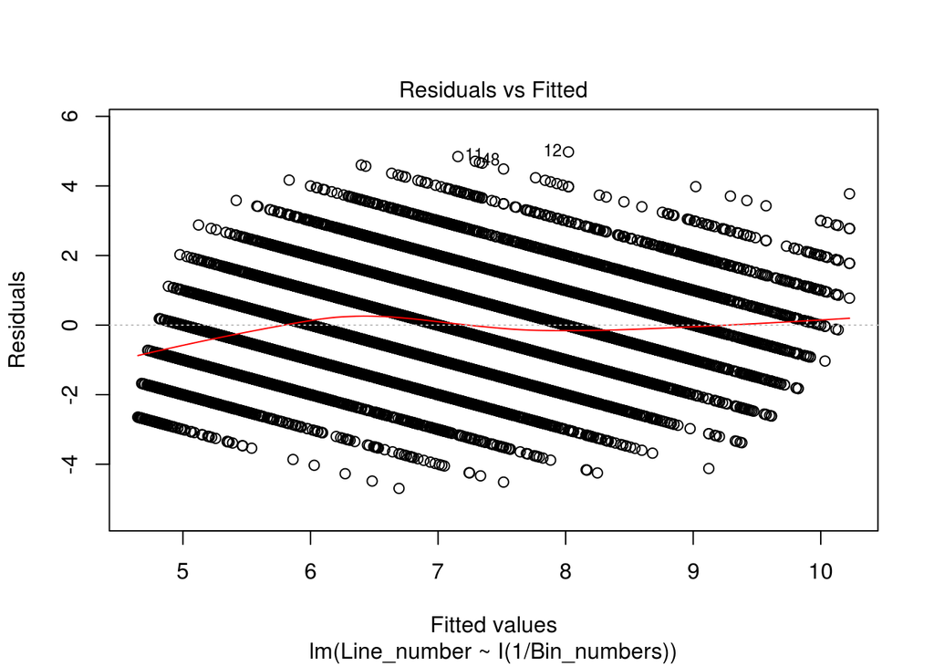

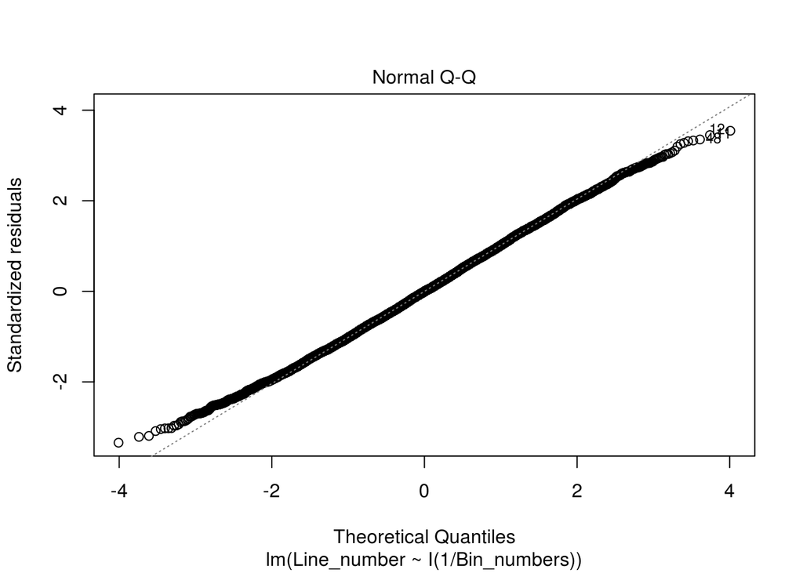

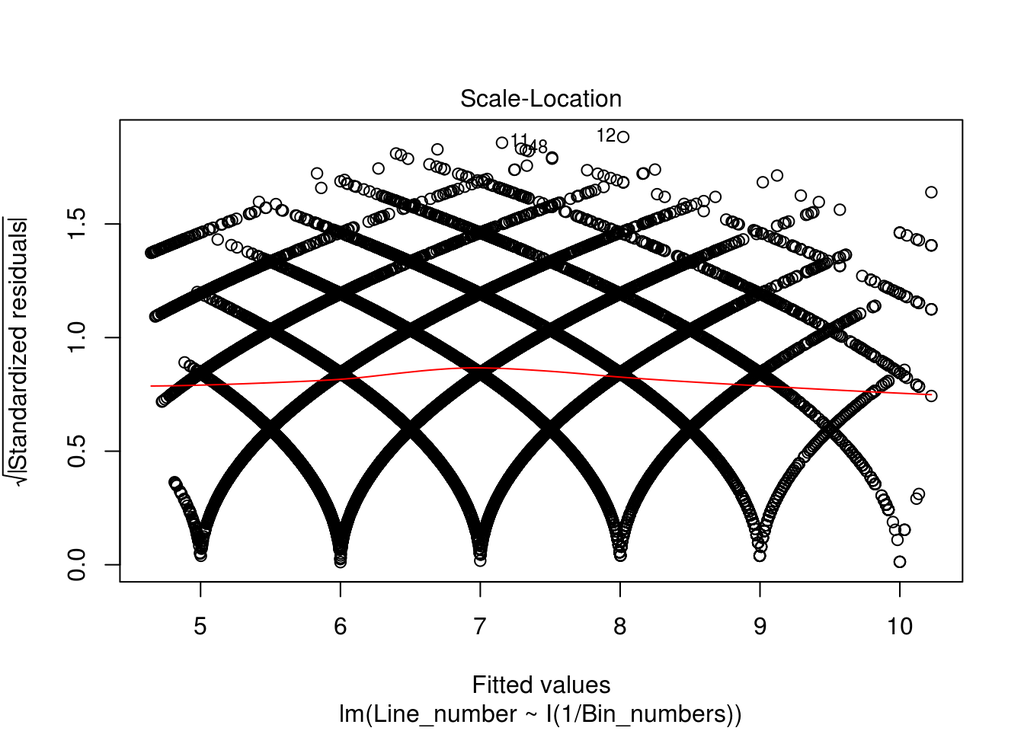

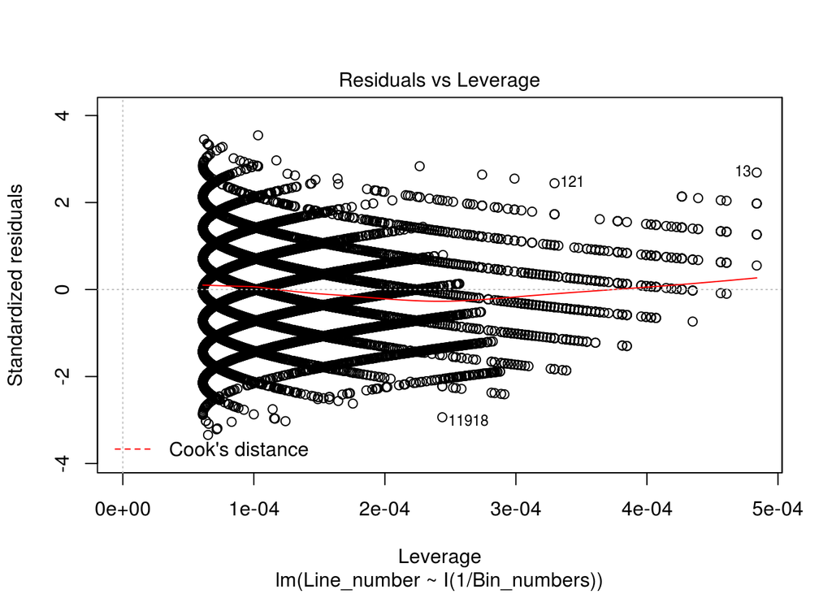

```r
#R^2 отстойный, да и хуй бы с ним

#Непонятные метрики
plot(fit_natural)
```

Теперь попробуем предсказать, сколько у нас будет пересечений при увеличении количества линий до 30, например

```r
x <- c(1:100)
y <- fit_natural$coefficients[1] + fit_natural$coefficients[2]/x
y
```

```
##   [1] 1740.86886  872.74663  583.37255  438.68551  351.87329  293.99847
##   [7]  252.65932  221.65495  197.54045  178.24884  162.46480  149.31143
##  [13]  138.18166  128.64186  120.37403  113.13968  106.75642  101.08242
##  [19]   96.00568   91.43662   87.30270   83.54460   80.11329   76.96792
##  [25]   74.07417   71.40303   68.92975   66.63313   64.49490   62.49921
##  [31]   60.63228   58.88204   57.23786   55.69041   54.23138   52.85341
##  [37]   51.54992   50.31504   49.14349   48.03051   46.97182   45.96355
##  [43]   45.00217   44.08450   43.20761   42.36884   41.56577   40.79616
##  [49]   40.05796   39.34929   38.66841   38.01371   37.38373   36.77707
##  [55]   36.19248   35.62876   35.08483   34.55965   34.05227   33.56180
##  [61]   33.08742   32.62834   32.18383   31.75322   31.33585   30.93113
##  [67]   30.53849   30.15740   29.78736   29.42789   29.07854   28.73890
##  [73]   28.40857   28.08716   27.77432   27.46972   27.17303   26.88394
##  [79]   26.60217   26.32745   26.05951   25.79811   25.54300   25.29397
##  [85]   25.05080   24.81329   24.58123   24.35445   24.13276   23.91600
##  [91]   23.70401   23.49662   23.29369   23.09508   22.90065   22.71028
##  [97]   22.52382   22.34118   22.16222   21.98684
```

Асимптота - получилась равна 4.6243965 - но хрен мы к нему приблизимся, раньше все зашкварят погрешности эксперимента

### Сгенерерированные пересечения

Тоже зафиттим обратно-пропорциональную зависимость по средним значениям

```r
#Для начала попробуем зафиттить по средним
temp_generated <- generated_df[, round(mean(Bin_numbers), digits = 0), by = Line_number]
temp_generated <- temp_generated[temp_generated$V1 != 0] #убрали нули
fit_mean_generated <- lm(Line_number ~ I(1/V1), temp_generated)

#Что мы имеем
summary(fit_mean_generated)
```

```
##
## Call:
## lm(formula = Line_number ~ I(1/V1), data = temp_generated)
##
## Residuals:
##       1       2       3       4       5       6       7
## -2.3574 -1.3576 -0.3588  0.6336  1.5835  2.1505 -0.2938
##
## Coefficients:
##             Estimate Std. Error t value Pr(>|t|)
## (Intercept)   3.3574     0.7281   4.611  0.00578 **
## I(1/V1)      11.8092     5.7342   2.059  0.09450 .
## ---
## Signif. codes:  0 '***' 0.001 '**' 0.01 '*' 0.05 '.' 0.1 ' ' 1
##
## Residual standard error: 1.741 on 5 degrees of freedom
## Multiple R-squared:  0.4589, Adjusted R-squared:  0.3507
## F-statistic: 4.241 on 1 and 5 DF,  p-value: 0.0945
```

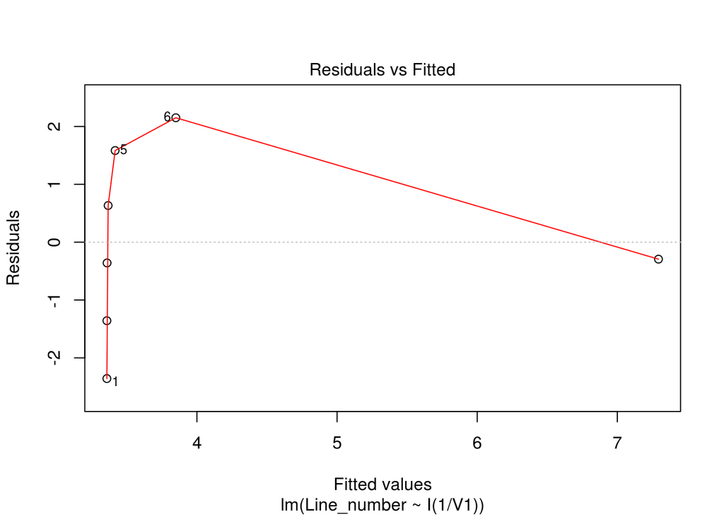

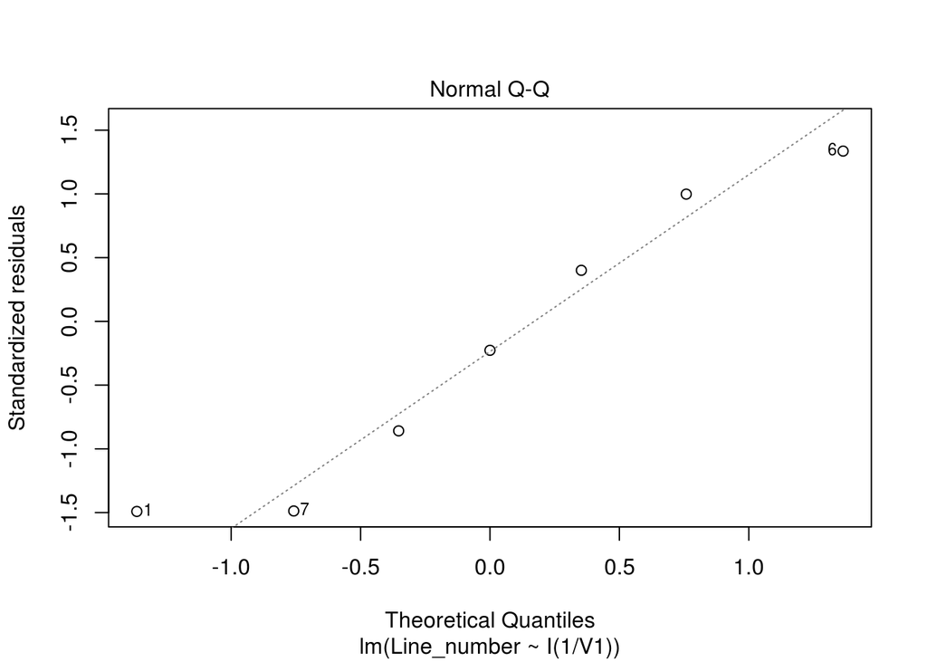

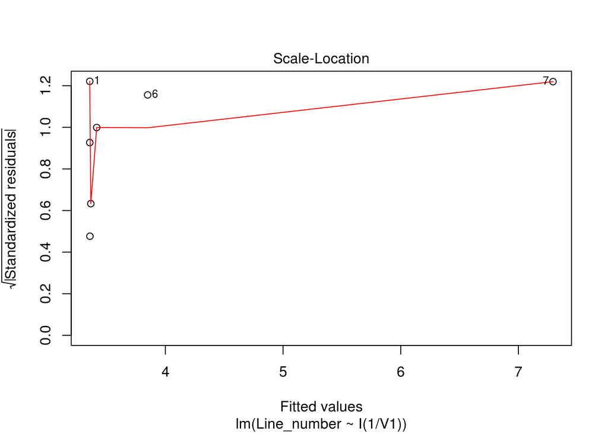

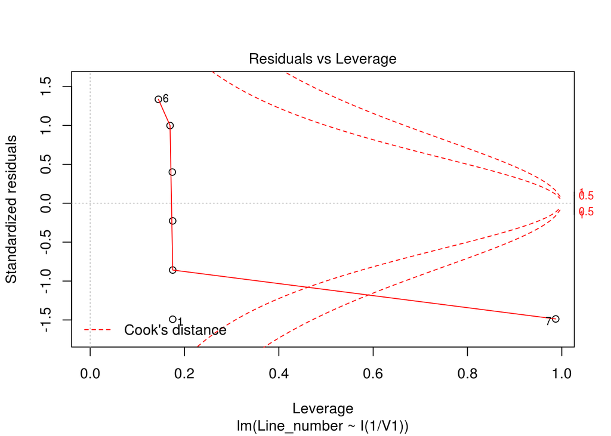

```r
#Выглядит плохо совсем

#Немного непонятных метрик
plot(fit_mean_generated)
```

Не очень удалось

Попробуем зафиттить линейную модель

```r
temp_generated <- generated_df[, round(mean(Bin_numbers), digits = 0), by = Line_number]
fit_mean_generated <- lm(Line_number ~ V1, temp_generated)

#Что мы имеем
summary(fit_mean_generated)
```

```
##
## Call:
## lm(formula = Line_number ~ V1, data = temp_generated)
##
## Residuals:
##     Min      1Q  Median      3Q     Max
## -5.1412 -2.8952  0.3028  2.6023  5.8523
##
## Coefficients:
##               Estimate Std. Error t value Pr(>|t|)
## (Intercept)  8.148e+00  1.056e+00   7.718 5.42e-06 ***
## V1          -1.592e-05  7.894e-06  -2.017   0.0667 .
## ---
## Signif. codes:  0 '***' 0.001 '**' 0.01 '*' 0.05 '.' 0.1 ' ' 1
##
## Residual standard error: 3.763 on 12 degrees of freedom
## Multiple R-squared:  0.2531, Adjusted R-squared:  0.1909
## F-statistic: 4.067 on 1 and 12 DF,  p-value: 0.06668
```

```r
#Выглядит плохо совсем
```

Еще хуже выглядит

Попробуем exp(-x)

```r
fit_mean_generated <- lm(Line_number ~ I(exp(-V1)), temp_generated)

#Что мы имеем
summary(fit_mean_generated)
```

```
##
## Call:
## lm(formula = Line_number ~ I(exp(-V1)), data = temp_generated)
##
## Residuals:
##      Min       1Q   Median       3Q      Max
## -3.01932 -1.70252  0.02521  1.75294  2.98068
##
## Coefficients:
##             Estimate Std. Error t value Pr(>|t|)
## (Intercept)   3.9303     0.8074   4.868 0.000386 ***
## I(exp(-V1))   7.0891     1.1416   6.210 4.52e-05 ***
## ---
## Signif. codes:  0 '***' 0.001 '**' 0.01 '*' 0.05 '.' 0.1 ' ' 1
##
## Residual standard error: 2.121 on 12 degrees of freedom
## Multiple R-squared:  0.7627, Adjusted R-squared:  0.7429
## F-statistic: 38.56 on 1 and 12 DF,  p-value: 4.52e-05
```

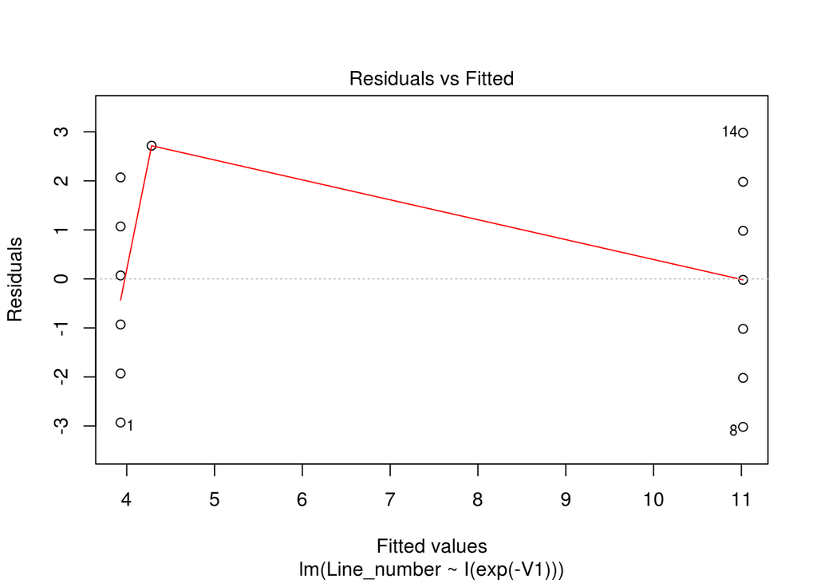

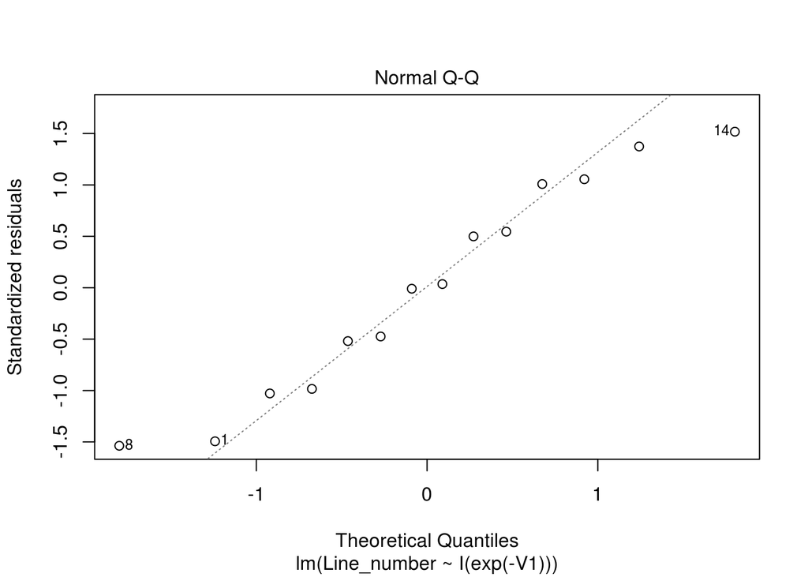

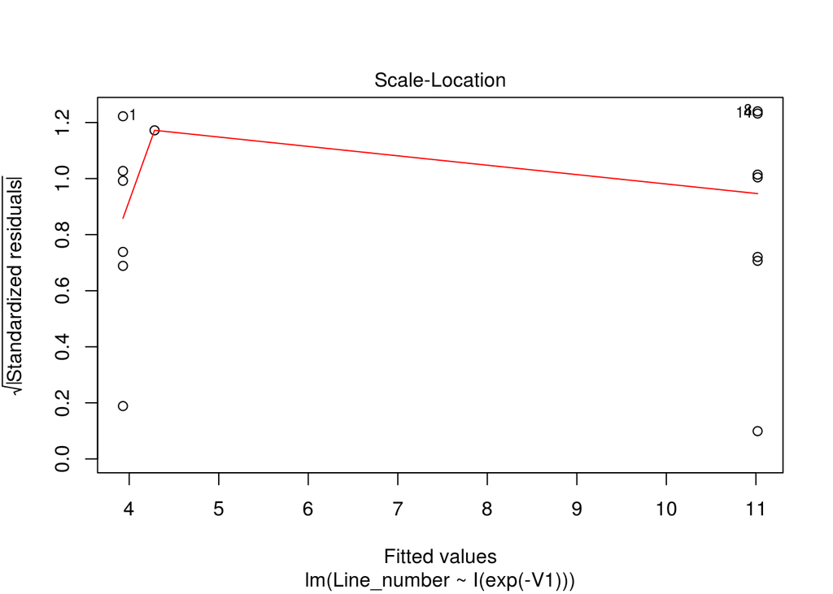

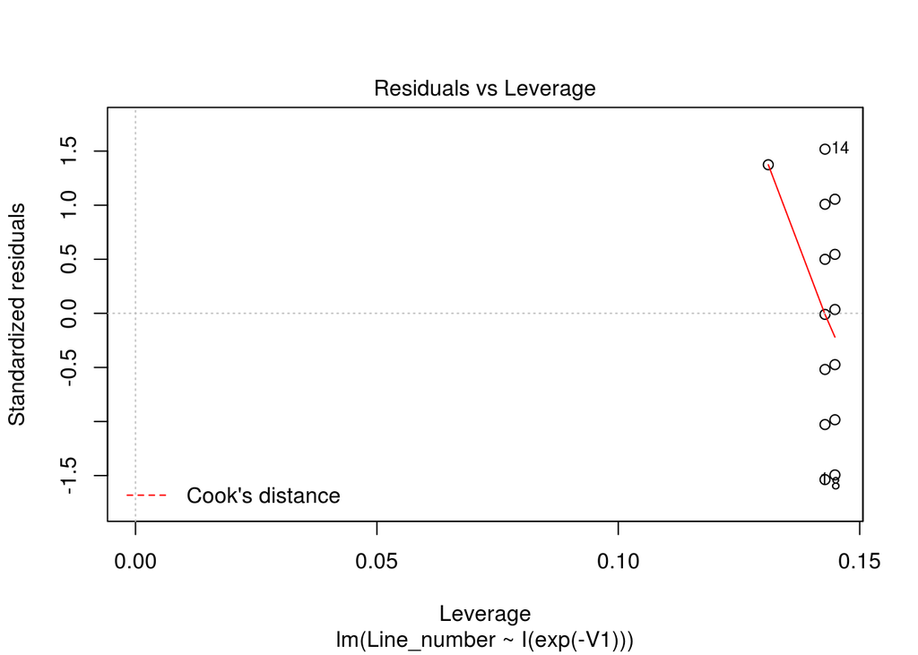

```r
#Выглядит нормальненько

#Немного непонятных метрик
plot(fit_mean_generated)
```

Вроде как подтвердили, что зависимость есть, давай теперь попробуем предсказать реальные значения по всем точкам

```r
fit_generated <- lm(Line_number ~ I(exp(-Bin_numbers)), generated_df)

#Что мы имеем
summary(fit_generated)
```

```
##
## Call:
## lm(formula = Line_number ~ I(exp(-Bin_numbers)), data = generated_df)
##
## Residuals:
##     Min      1Q  Median      3Q     Max
## -8.5892 -1.5892  0.4108  2.4108  5.5302
##
## Coefficients:
##                      Estimate Std. Error t value Pr(>|t|)
## (Intercept)           3.46969    0.05841   59.40   <2e-16 ***
## I(exp(-Bin_numbers))  6.11952    0.07226   84.69   <2e-16 ***
## ---
## Signif. codes:  0 '***' 0.001 '**' 0.01 '*' 0.05 '.' 0.1 ' ' 1
##
## Residual standard error: 2.833 on 6998 degrees of freedom
## Multiple R-squared:  0.5061, Adjusted R-squared:  0.5061
## F-statistic:  7172 on 1 and 6998 DF,  p-value: < 2.2e-16
```

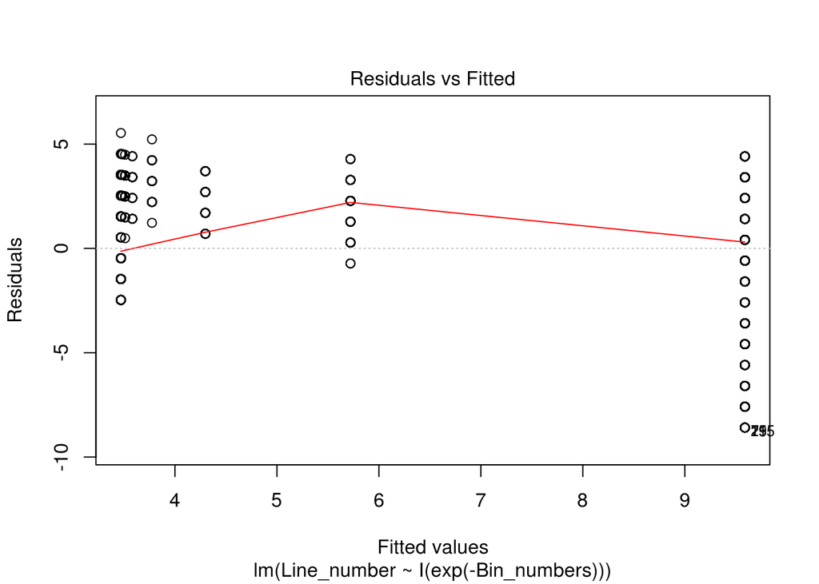

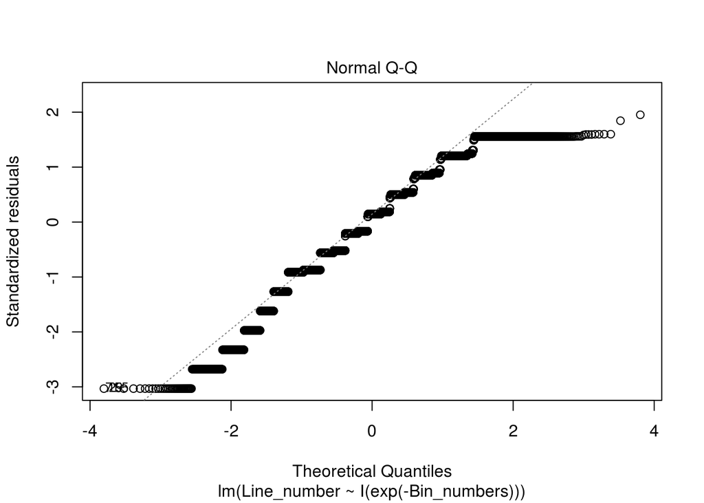

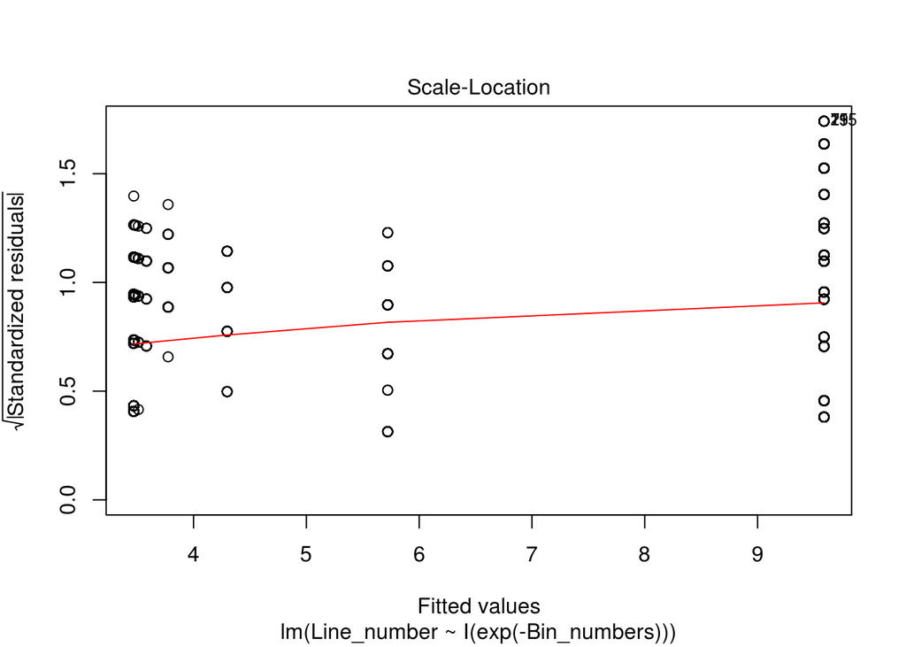

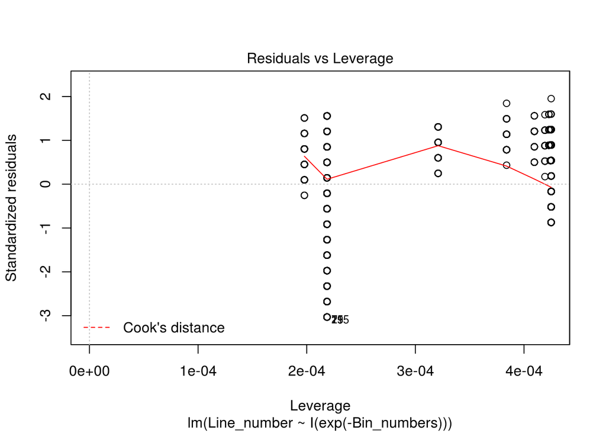

```r
#Выглядит нормальненько

#Немного непонятных метрик
plot(fit_generated)
```

А теперь предскажем, как поведет себя количество пересечений при увеличении количества линий

```r
x <- c(1:100)
y <- fit_generated$coefficients[1] + fit_generated$coefficients[2]*exp(-x)
y
```

```
##   [1] 5.720933 4.297875 3.774361 3.581771 3.510921 3.484856 3.475268
##   [8] 3.471741 3.470443 3.469966 3.469790 3.469725 3.469702 3.469693
##  [15] 3.469690 3.469688 3.469688 3.469688 3.469688 3.469688 3.469688
##  [22] 3.469688 3.469688 3.469688 3.469688 3.469688 3.469688 3.469688
##  [29] 3.469688 3.469688 3.469688 3.469688 3.469688 3.469688 3.469688
##  [36] 3.469688 3.469688 3.469688 3.469688 3.469688 3.469688 3.469688
##  [43] 3.469688 3.469688 3.469688 3.469688 3.469688 3.469688 3.469688
##  [50] 3.469688 3.469688 3.469688 3.469688 3.469688 3.469688 3.469688
##  [57] 3.469688 3.469688 3.469688 3.469688 3.469688 3.469688 3.469688
##  [64] 3.469688 3.469688 3.469688 3.469688 3.469688 3.469688 3.469688
##  [71] 3.469688 3.469688 3.469688 3.469688 3.469688 3.469688 3.469688
##  [78] 3.469688 3.469688 3.469688 3.469688 3.469688 3.469688 3.469688
##  [85] 3.469688 3.469688 3.469688 3.469688 3.469688 3.469688 3.469688
##  [92] 3.469688 3.469688 3.469688 3.469688 3.469688 3.469688 3.469688
##  [99] 3.469688 3.469688
```

Выглядит странно, но что уж тут поделаешь, суть не меняется.

## Обобщенная статистика по общим регионам

Интересно, что же там такое?